# Reproducible Research - PA1_template

## Q1 Loading and preprocessing the data

```r
Sys.setlocale("LC_TIME", "English")
```

```
## [1] "English_United States.1252"
```

```r
if(!file.exists("activity.csv")) {
  temp <- tempfile()
  download.file("http://d396qusza40orc.cloudfront.net/repdata%2Fdata%2Factivity.zip",temp)
  unzip(temp)
  unlink(temp)
}
activity <- read.csv("activity.csv")
summary(activity)
```

```
##      steps                date          interval
##  Min.   :  0.00   2012-10-01:  288   Min.   :   0.0
##  1st Qu.:  0.00   2012-10-02:  288   1st Qu.: 588.8
##  Median :  0.00   2012-10-03:  288   Median :1177.5
##  Mean   : 37.38   2012-10-04:  288   Mean   :1177.5
##  3rd Qu.: 12.00   2012-10-05:  288   3rd Qu.:1766.2
##  Max.   :806.00   2012-10-06:  288   Max.   :2355.0
##  NA's   :2304     (Other)   :15840
```

```r
library(lubridate)
```

```r
activity$date <- ymd(activity$date)
str(activity)
```

```
## 'data.frame':    17568 obs. of  3 variables:
##  $ steps   : int  NA NA NA NA NA NA NA NA NA NA ...
##  $ date    : Date, format: "2012-10-01" "2012-10-01" ...
##  $ interval: int  0 5 10 15 20 25 30 35 40 45 ...
```

```r
require(dplyr)
```

```r
totalStepsPerDay <- activity %>% group_by(date) %>%summarise(totalSteps=sum(steps),na=sum(is.na(steps))) %>% print
```

```
## # A tibble: 61 × 3
##          date totalSteps    na
##        <date>      <int> <int>
## 1  2012-10-01         NA   288
## 2  2012-10-02        126     0
## 3  2012-10-03      11352     0
## 4  2012-10-04      12116     0
## 5  2012-10-05      13294     0
## 6  2012-10-06      15420     0
## 7  2012-10-07      11015     0
## 8  2012-10-08         NA   288
## 9  2012-10-09      12811     0
## 10 2012-10-10       9900     0
## # ... with 51 more rows
```

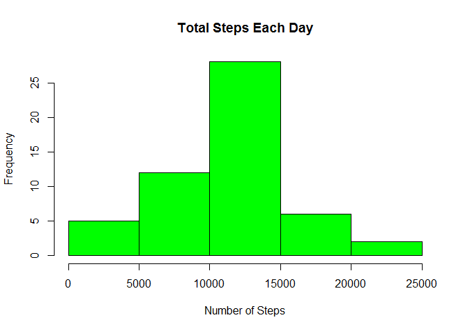

```r
hist(totalStepsPerDay$totalSteps, main =paste("Total Steps Each Day"), xlab="Number of Steps",col="green")
```

```r
meanSteps <- mean(totalStepsPerDay$totalSteps,na.rm=TRUE)
medianSteps <- median(totalStepsPerDay$totalSteps,na.rm=TRUE)
```

```r
meanSteps
```

```
## [1] 10766.19
```

```r
medianSteps
```

```
## [1] 10765
```

## Q3 What is the average daily activity pattern

```r
library(ggplot2)
```

```r
stepsByInterval <- activity%>%group_by(interval)%>%summarise(average_steps=mean(steps, na.rm=TRUE))
head(stepsByInterval)
```

```
## # A tibble: 6 × 2
##   interval average_steps
##      <int>         <dbl>
## 1        0     1.7169811
## 2        5     0.3396226
## 3       10     0.1320755
## 4       15     0.1509434
## 5       20     0.0754717
## 6       25     2.0943396
```

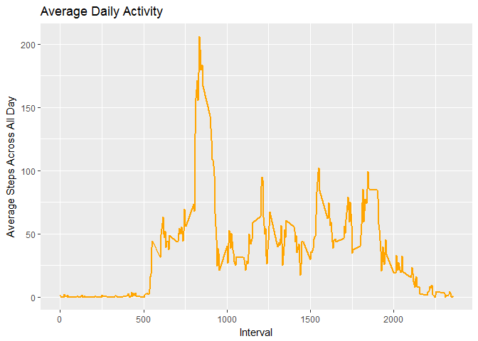

```r
ggplot(stepsByInterval, aes(x =interval , y=average_steps)) +
  geom_line(color="orange", size=1) +
  labs(title = "Average Daily Activity", x = "Interval", y = "Average Steps Across All Day")
```

```r
maxInterval <- stepsByInterval[which.max(stepsByInterval$average_steps),]
maxInterval
```

```
## # A tibble: 1 × 2
##   interval average_steps
##      <int>         <dbl>
## 1      835      206.1698
```

## Q4 Imputing missing values

1. Calculate and report the total number of missing values in the dataset (i.e. the total number of rows with NAs)##

```r
sum(is.na(activity$steps))
```

```
## [1] 2304
```

2. Devise a strategy for filling in all of the missing values in the dataset.

Strategy: filling in missing data with the mean number of steps across all days with available data for that particular interval.

3. Create a new dataset that is equal to the original dataset but with the missing data filled in.

```r
StepsPerInterval <- tapply(activity$steps, activity$interval, mean, na.rm = TRUE)

activitySplit <- split(activity, activity$interval)

for(i in 1:length(activitySplit)){
  activitySplit[[i]]$steps[is.na(activitySplit[[i]]$steps)] <- StepsPerInterval[i]
}
activityNoNas <- do.call("rbind", activitySplit)
activityNoNas <- activityNoNas[order(activityNoNas$date),]
```

4. Make a histogram of the total number of steps taken each day and Calculate and report the mean and median total number of steps taken per day.

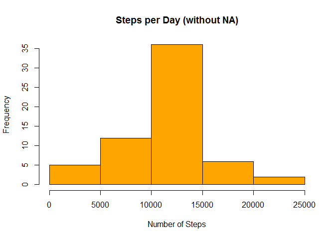

```r
StepsPerDayNoNas<- tapply(activityNoNas$steps, activityNoNas$date, sum)

hist(StepsPerDayNoNas, xlab = "Number of Steps", main = "Steps per Day (without NA)", col="orange")
```

```r
MeanPerDayNoNas <- mean(StepsPerDayNoNas, na.rm = TRUE)
MeanPerDayNoNas
```

```
## [1] 10766.19
```

```r
MedianPerDayNoNas <- median(StepsPerDayNoNas, na.rm = TRUE)
MedianPerDayNoNas
```

```
## [1] 10766.19
```

## Q5 Are there differences in activity patterns between weekdays and weekends?

1. Create a new factor variable in the dataset with two levels – “weekday” and “weekend” indicating whether a given date is a weekday or weekend day.

```r
activityNoNas$day <- ifelse(weekdays(as.Date(activityNoNas$date),abbreviate = FALSE) == "Saturday" | weekdays(as.Date(activityNoNas$date),abbreviate = FALSE) == "Sunday", "weekend", "weekday")
```

2.Make a panel plot containing a time series plot (i.e. type = “l”) of the 5-minute interval (x-axis) and the average number of steps taken, averaged across all weekday days or weekend days (y-axis)

```r
StepsPerIntervalWeekend <- tapply(activityNoNas[activityNoNas$day == "weekend" ,]$steps, activityNoNas[activityNoNas$day == "weekend" ,]$interval, mean, na.rm = TRUE)

StepsPerIntervalWeekday <- tapply(activityNoNas[activityNoNas$day == "weekday" ,]$steps, activityNoNas[activityNoNas$day == "weekday" ,]$interval, mean, na.rm = TRUE)
```

Plots of weekdays and weekend activity

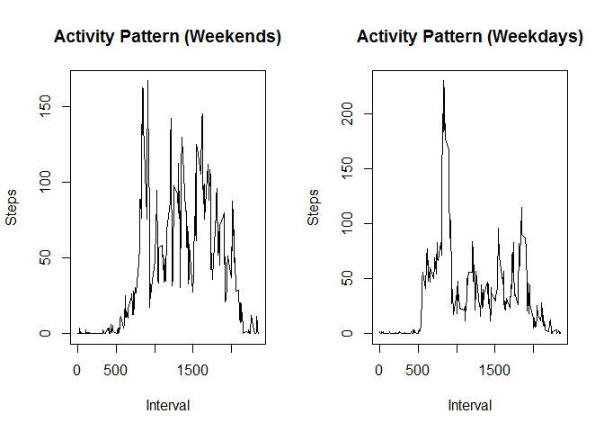

```r
par(mfrow=c(1,2))
#Weekend activity - plot
plot(as.numeric(names(StepsPerIntervalWeekend)),
     StepsPerIntervalWeekend,
     xlab = "Interval",
     ylab = "Steps",
     main = "Activity Pattern (Weekends)",
     type = "l")
#Weekday activity - plot
plot(as.numeric(names(StepsPerIntervalWeekday)),
     StepsPerIntervalWeekday,
     xlab = "Interval",
     ylab = "Steps",
     main = "Activity Pattern (Weekdays)",
     type = "l")
```